# Statistik och dataanalys I

F3: Samband mellan kategoriska variabler

Valentin Zulj

## Dagens föreläsning

- Frekvenstabeller
- Korstabeller
  - Simultana-, marginella-, relativa-, och betingade fördelningar
- Kategoriska variabler och samband
  - Kausalitet och Simpsons paradox

# Frekvenstabeller

## En variabel

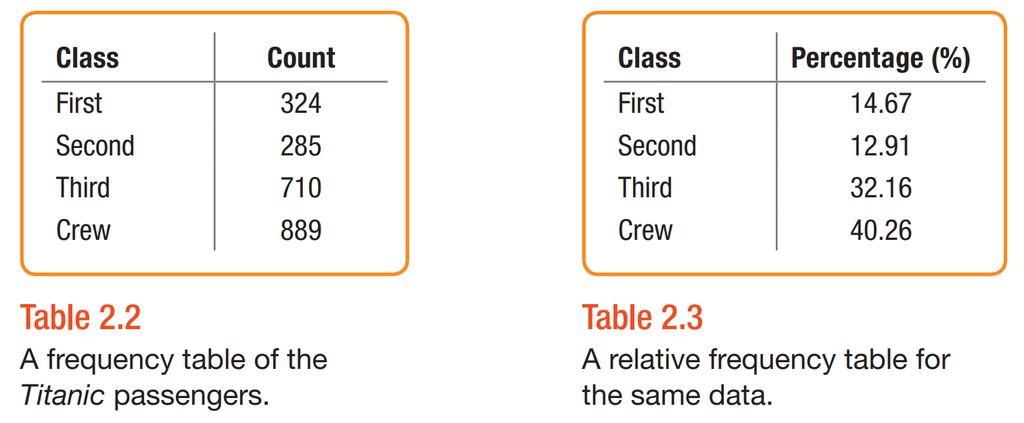

- En frekvenstabell redovisar antalet observationer i varje kategori
- En relativ frekvenstabell visar andel istället för antal
- Har vi flera kategoriska variabler kan vi göra en frekvenstabell per variabel
- Tabeller över enskilda variabler visar dock **inte samband** mellan variabler

# Korstabeller

## Två kategoriska variabler

- En variabel delar in deltagare i **kategorier baserat på hur ofta de äter fisk:**
  - Sällan/adrig, lite, måttligt, mycket
- Den andra variabeln delar in deltagarna i **två kategorier:**
  - Diagnosticerades/diagonsticerades inte med prostatacancer under studieperioden

## Två kategoriska variabler – Korstabeller i R

- För att skapa en korstabell i `R` använder vi funktionen `tally()`
- Skillnaden mot en frekvenstabell är att vi lägger till en extra variabel efter ett plustecken

```r
tally(~ diet + cancer, data=fish, format="count")
```

```
          cancer
diet         No  Yes
  Never     110   14
  Small    2420  201
  Moderate 2769  209
  Large     507   42
```

## Marginalfördelningar

- **Marginalfördelningen** för **den ena variabeln** visar antalet observationer per kategori, utan att vi tar någon hänsyn till den andra variabeln
- Tabellens högermarignal ger marginalfördelningen för “Fish Consumption”
- Vi ser t.ex. att totalt 124 deltagare sällan/aldrig åt fisk, och tar ingen hänsyn till “Prostate Cancer”

## Marginalfördelningar

- Tabellens bottenmarginal visar marginalfördelningen för variabeln “Prostate Cancer”
- Totalt 466 testdeltagare diagnostiserades med prostatacaner under studien
- Varje marginalfördelning summerar till det totala antalet observationer:  
  $124+2621+2978+549=5806+466=6272$

## Marginalfördelningar

- Marginalfördelningen för en kategorisk variabel är samma fördelning som den vi ser i frekvenstabellen när vi bara inkluderar en variabel
- För att bekräfta det skriver vi först ut en korstabell i R (notera att `margins = TRUE` lägger till marginaler)
- Sedan skriver vi ut frekvenstabellerna för de två variablerna var för sig

```r
tally(~ diet + cancer, data=fish, format="count", margins=TRUE)
```

```
          cancer
diet         No  Yes Total
  Never     110   14   124
  Small    2420  201  2621
  Moderate 2769  209  2978
  Large     507   42   549
  Total    5806  466  6272
```

## Marginalfördelningar

```r
tally(~ diet + cancer, data=fish, format="count", margins=TRUE)
```

```
          cancer
diet         No  Yes Total
  Never     110   14   124
  Small    2420  201  2621
  Moderate 2769  209  2978
  Large     507   42   549
  Total    5806  466  6272
```

```r
tally(~ diet, data=fish, format="count", margins=TRUE)
```

```
diet
   Never    Small Moderate    Large    Total
     124     2621     2978      549     6272
```

```r
tally(~ cancer, data=fish, format="count", margins=TRUE)
```

```
cancer
   No   Yes Total
 5806   466  6272
```

## Relativa fördelningar

- Genom att dela varje frekvens med det totala antalet observationer, och sedan multiplicera med 100, kan vi få en **relativ frekvenstabell**
- Antalet som åt mycket fisk och som inte fick cancer var exempelvis 507, så motsvarande andel blir

$$\cfrac{507}{6272}\cdot 100\% = 8.0835 \%.$$

## Relativa fördelningar

- Om vi sätter `format="percent"` i `tally()` får vi en korstabell med relativa frekvenser

```r
tally(~ diet + cancer, data=fish, format="percent", margins=TRUE)
```

```
          cancer
diet                No         Yes       Total
  Never      1.7538265   0.2232143   1.9770408
  Small     38.5841837   3.2047194  41.7889031
  Moderate  44.1485969   3.3322704  47.4808673
  Large      8.0835459   0.6696429   8.7531888
  Total     92.5701531   7.4298469 100.0000000
```

- Vi har dock fortfarande inte sett någon tabell som enkelt låter oss se samband mellan variablerna, vilket var syftet med korstabellen
- Vi vänder oss därför till *betingade fördelningar*

## Betingade fördelningar

- För att kunna se samband mellan variablerna introducerar vi begreppet **betingad fördelning** (*en: conditional distribution*)
- En betingad fördelning är fördelningen av en variabel **givet** ett värde av en annan variabel
- Vi kan exempelvis vilja undersöka sambandet mellan prostatacancer och fisk i dieten genom att ställa frågorna:
  - Hur stor andel av de som *aldrig/sällan* åt fisk fick prostatacancer?
  - Hur stor andel av de som åt *lite fisk* fick prostatacancer?
  - Hur stor andel av de som åt *måttligt med fisk* fick prostatacancer?
  - Hur stor andel av de som åt *mycket fisk* fick prostatacancer?

## Betingade fördelningar

- När vi ställer de här frågorna är vi intresserade av risken för prostatacancer **betingat på** en viss diet
- För att få svaren tittar vi på en diet-kategori i taget, där en diet-kategori definieras av hur ofta en person äter fisk
- Genom att jämföra personer som tillhör olika diet-kategorier kan vi se om det finns samband

## Betingade fördelningar

- När vi räknar ut betingade fördelningar intresserar vi oss bara för den kategori som vi betingar på
- Vill vi ha fördelningen av variabeln prostatacancer betingat på att individen aldrig/sällan äter fisk, ignorerar vi dem som inte tillhör den kategorin

## Betingade fördelningar

- När vi räknar ut betingade fördelningar intresserar vi oss bara för den kategori som vi betingar på
- Vill vi ha fördelningen av variabeln prostatacancer betingat på att individen aldrig/sällan äter fisk, ignorerar vi dem som inte tillhör den kategorin

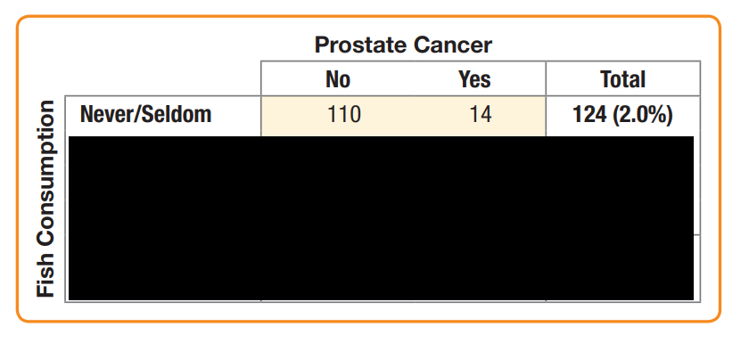

## Betingade fördelningar

> - 14 deltagare fick prostatacancer, och 110 fick inte det.
> - Vi tar fram den relativa frekvensen på samma sätt som när vi bara har en variabel
> - Andelen med cancer är $14/124=0.1129$ och andelen utan cancer är $110/124=0.8871$
> - Detta är vår betingade fördelning.

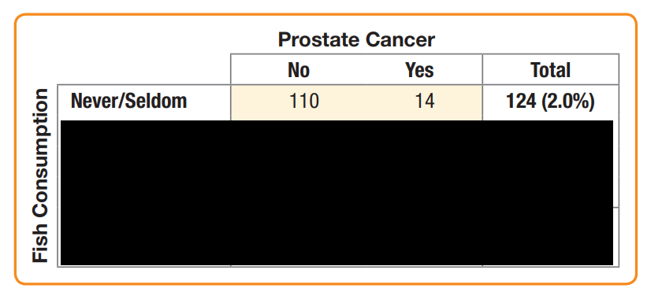

## Betingade fördelningar

- Vi kan använda `R` för att skapa en tabell som visar den betingade fördelningen för varje kategori
- I `tally()` skriver vi `cancer|diet`, som uttalas *cancer givet diet*
- Tabellen nedan anger fördelningen i procent, vilket är mycket vanligt

```r
# Tillägget |> t() vänder på tabellen. Testa både med och utan.
tally(~cancer|diet,data=fish,format="percent",margins=TRUE) |> t()
```

```
          cancer
diet               No        Yes      Total
  Never     88.709677  11.290323 100.000000
  Small     92.331171   7.668829 100.000000
  Moderate  92.981867   7.018133 100.000000
  Large     92.349727   7.650273 100.000000
```

## Betingade fördelningar

- Notera att **varje rad** summerar till 100 procent, eftersom varje rad representerar en av de kategorier som vi betingar fördelningen på
- Varje rad i tabellen kan alltså ses som en egen självständig fördelning
- Med denna tabell kan vi visa skillnader mellan grupperna på ett nytt sätt
  - Bland dem som aldrig eller sällan åt fisk hade drygt 11 procent diagnosticerats med prostatacancer
  - Bland övriga grupper är motsvarande siffra lite över 7 procent

```
          cancer
diet               No        Yes      Total
  Never     88.709677  11.290323 100.000000
  Small     92.331171   7.668829 100.000000
  Moderate  92.981867   7.018133 100.000000
  Large     92.349727   7.650273 100.000000
```

## Kategoriska variabler och samband

Vi kan ge en snabbare överblick av samma information med en graf

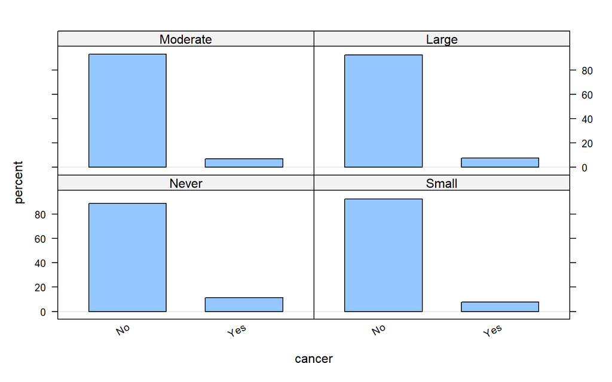

```r
bargraph(~cancer|diet, data=fish, type="percent")
```

## Kategoriska variabler och samband

- Vi kan också gruppera efter variabeln cancer
- Färgerna indikerar diet, och två staplar av samma färg summerar till 100%
- Vi ser att cancer förekom något mer bland deltagare som aldrig/sällan åt fisk

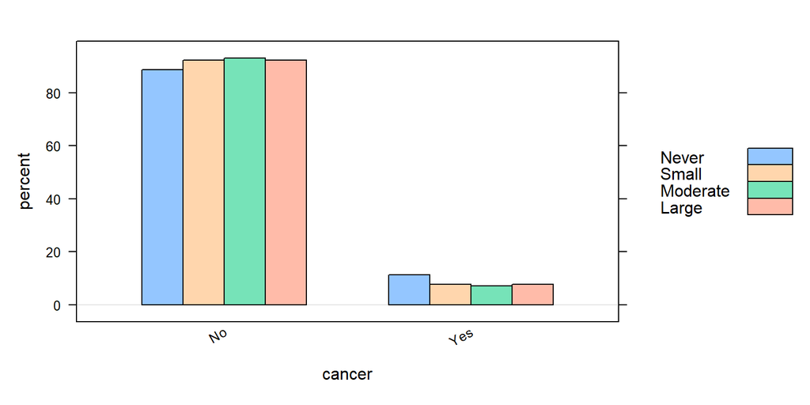

```r
bargraph(~cancer, groups=diet, data=fish, type="percent")
```

## Kategoriska variabler och samband

- Givet en viss diet kan vi nu säga hur stor andel som har diagnosticerats med cancer
- Betyder det att vi även kan säga hur stor andel av dem som diagnosticerat med cancer som har en viss diet?
- **Nej, inte utan att räkna ut nya betingade värden**
- Den här gången vill vi veta hur ofta personer äter fisk
  - betingat på att en person har diagnosticerats med cancer.
  - betingat på att en person inte har diagnosticerats med cancer.

## Kategoriska variabler och samband

- Vi tar den här gången fram en tabell som är betingad på cancer-variabeln
- Säg att vi vill räkna ut andelen som aldrig/sällan åt fisk betingat på att de fick cancer, vi gör då på liknande sätt som tidigare:
  - Vi *ignorerar* då alla deltagare som *inte* fick cancer
  - Antalet deltagare som fick prostatacancer var 466, och av åt 14 aldrig/sällan åt fisk
  - Bland dem som fick cancer var den procentuella andelen som aldrig/sällan åt fisk
    $$\frac{14}{466} \cdot 100 = 3.004292 \%$$

## Kategoriska variabler och samband

```r
tally(~ diet | cancer, data=fish, format="percent", margins=TRUE)
```

```
          cancer
diet               No        Yes
  Never      1.894592   3.004292
  Small     41.681020  43.133047
  Moderate  47.692043  44.849785
  Large      8.732346   9.012876
  Total    100.000000 100.000000
```

- För att göra motsvarande beräkning i `R` sätter vi `diet|cancer` i `tally()`
- Notera att det nu är **kolumnerna** som summerar till 100, då vi nu har gjort en separat frekvenstabell för varje kolumn
- Något som framgår här, och som vi inte såg när vi betingade fördelningen på diet, är att det är få av deltagarna som aldrig eller sällan äter fisk

## Kategoriska variabler och samband

- Vi gör ett stapeldiagram grupperat på cancer-variabeln
- De blå staplarna summerar till 100 procent, och staplarna i beige summerar också till 100 procent
- Vi ser att bland de som aldrig eller sällan äter fisk är cancerdiagnoserna något överrepresenterade

```r
bargraph(~diet, groups=cancer, data=fish, type="percent")
```

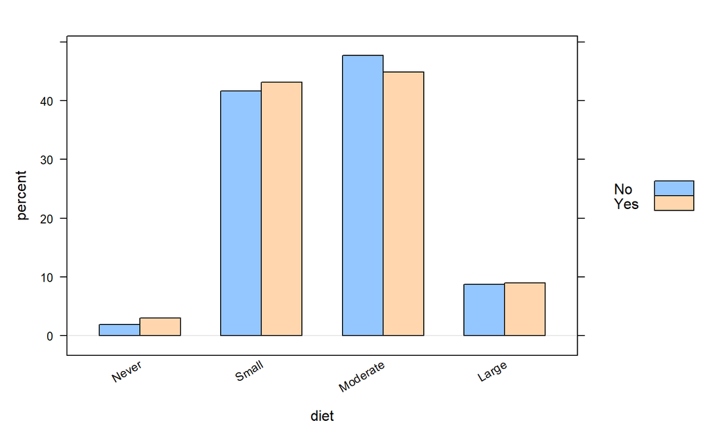

## Kategoriska variabler och samband - fler exempel

- Stapeldiagrammet till vänster är betingat på variabeln *Class*. Det hjälper oss att besvara frågan om hur stor andel som överlevde inom varje biljettklass
- Stapeldiagrammet till höger är betingat på variabeln *Survived*. Det hjälper oss att besvara frågan om hur stor andel av dem som överleve, respektive av dem som inte överlevde, som reste i en viss klass

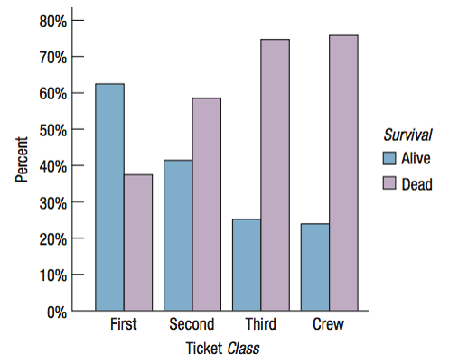

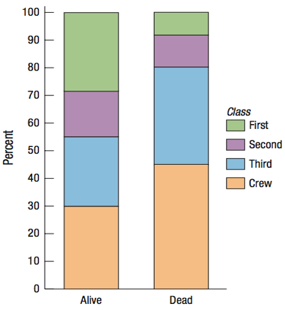

## Kategoriska variabler och samband - fler exempel

- Stapeldiagrammet till vänster ger en bild av andelen som överlevde katastrofen, men ingen information om hur många som ingick i varje klass
- Stapeldiagrammet till höger ger en bild av hur många som reste i respektive klass, men ingen information om andelen som överlevde

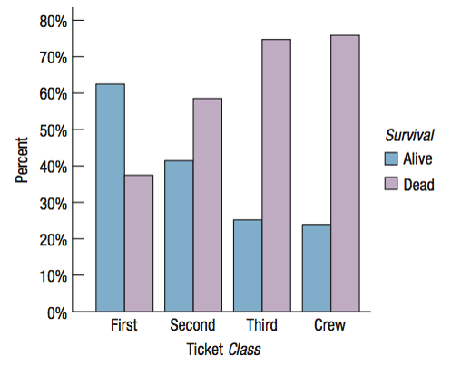

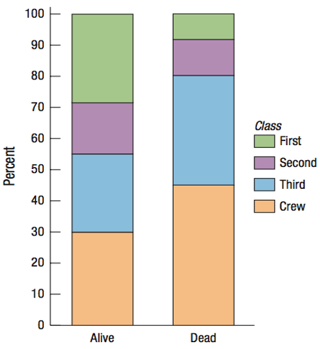

## Kategoriska variabler och samband - mosaic plot

- En **mosaic plot** ger en mer komplett bild av en simultan fördelning än ett vanligt stapeldiagram
- Varje ruta har en **area** som motsvarar andelen observationer som rutan representerar

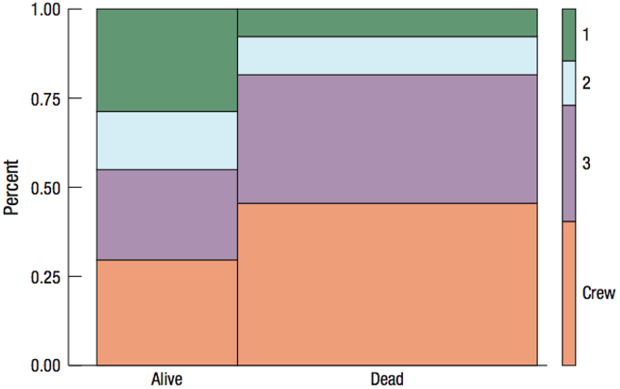

## Kategoriska variabler och samband - mosaic plot

- En mosaic plot kan dessutom visa fler än två variabler i samma bild
- Grafen nedan visar variablerna *Class*, *Survived* och *Gender*

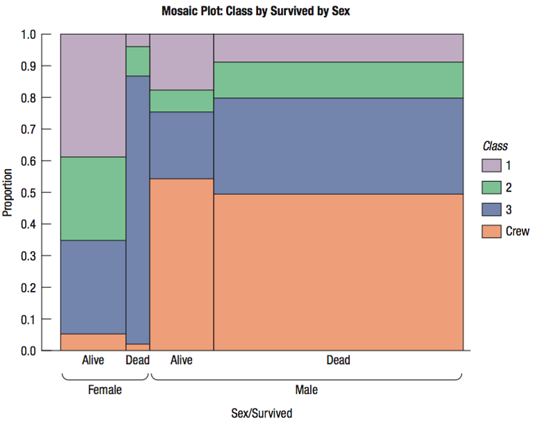

## Kategoriska variabler och samband - mosaic plot

- I `R` skapar vi en mosaic-plot med funktionen `mosaic()` i paketet `vcd`
- Ett exempel med studien om fisk och prostatacancer ges nedan, och ni kommer arbeta mer med detta i datorlab 3

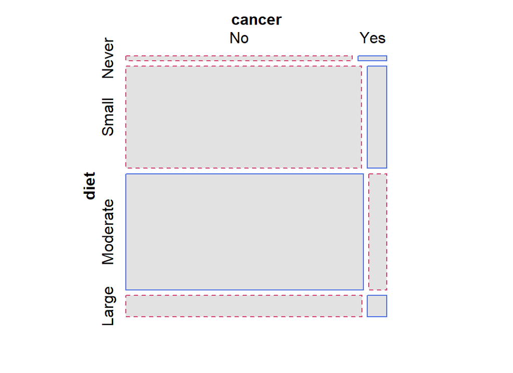

```r
mosaic(~diet + cancer, data=fish, shade=TRUE,
       gp=shading_Friendly2, legend=FALSE) #Kräver paketet vcd
```

## Kategoriska variabler och samband - fisk och cancer

- Det är tydligt att deltagare i studien som diagnosticerades med cancer var överrepresenterade bland dem som aldrig åt fisk
- Betyder det att vi har hittat ett samband? Ja och nej.
  - Ja, **bland deltagarna** i studien finns ett samband
  - Nej, vi kan inte utan vidare säga att det finns ett samband som gäller för **hela befolkningen**
- Det var bara 14 deltagare i studien som fick prostatacancer och som aldrig/sällan äter fisk, ett litet underlag om vi vill dra slutsatser gällande hela befolkningen
- Det kan vara slumpen som gör att vi ser ut att ha ett samband mellan två variabler

## Kategoriska variabler och samband - Titanic

- Vi vill avgöra om det sambandet vi ser i vårt stickprov beror på slumpen, eller om det faktiskt finns ett samband i populationen
- För att göra detta ger vi oss in i en gren av statistiken som kallas för **inferens**
- Formella metoder för inferens ingår i del 2 av kursen, men redan nu kan vi ge en mer allmän bild av vad det är

## Kategoriska variabler och samband - Titanic

- En forskare ställer frågan: Finns det ett samband mellan vilka som överlevde Titanic-katastrofen och vilket typ av biljett de reste med?
- Vi ser i vårt datamaterial att andelen som överlevde är störra i första klass än i tredje klass
  - Kan vi då säga att någon som reste i första klass hade större möjligheter att överleva?
  - Eller kan det like gärna ha varit slumpen som gjorde att en större andel ur första klass klarade sig?
- I kursboken (sid 48-49) beskrivs en metod som skulle kunna användas för att ge svar på frågan

## Kategoriska variabler och samband - Titanic

- Pajdiagrammet visar den faktiska fördelningen av passagerarkategorier bland dem som överlevde
- 1 står för 1:a klass, 2 för andra klass, 3 för tredje klass och Crew för besättning

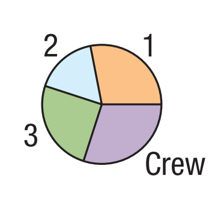

## Kategoriska variabler och samband - Titanic

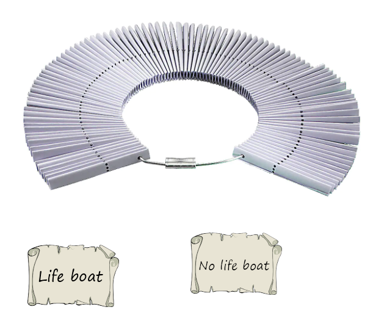

## Kategoriska variabler och samband - Titanic

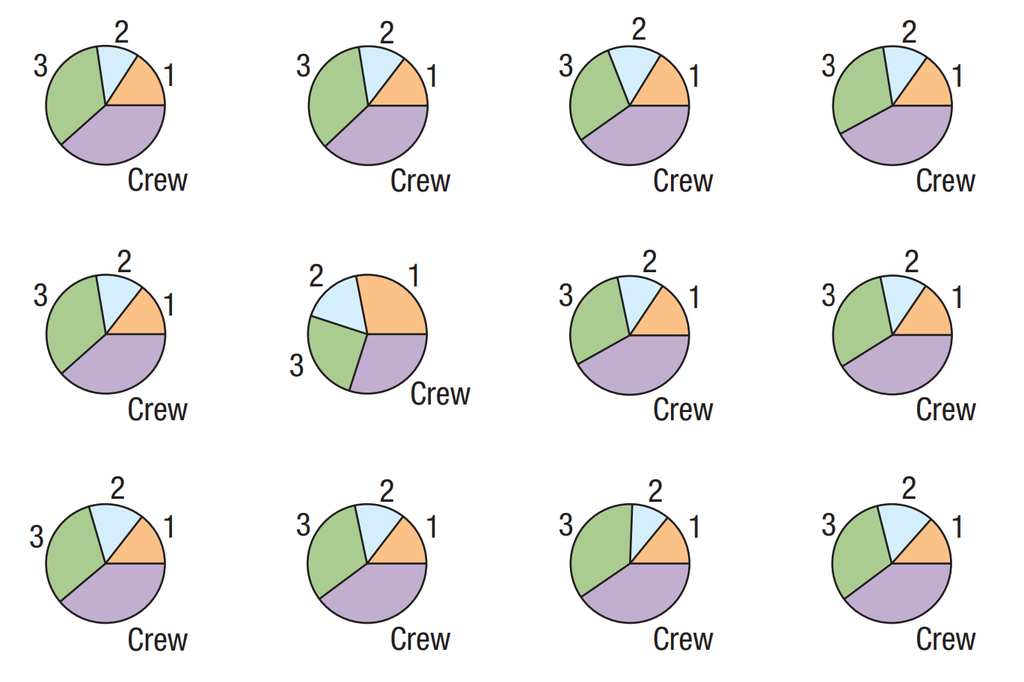

- Vi upprepar vår procedur att fördela platserna i livbåtarna flera gånger
- Varje gång gör vi ett nytt pajdiagram som visar utfallet

## Kategoriska variabler och samband - Titanic

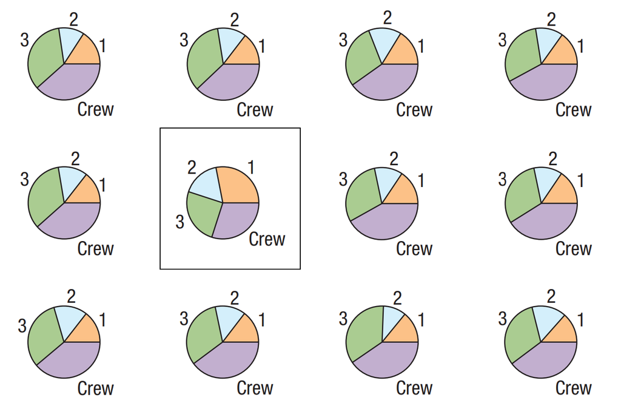

- Den verkliga fördelningen är markerad med en kvadrat
- Ser det ut som att den är resultatet av samma slumpvisa process som använts för att skapa de övriga fördelningarna?

## Kategoriska variabler och samband - Titanic

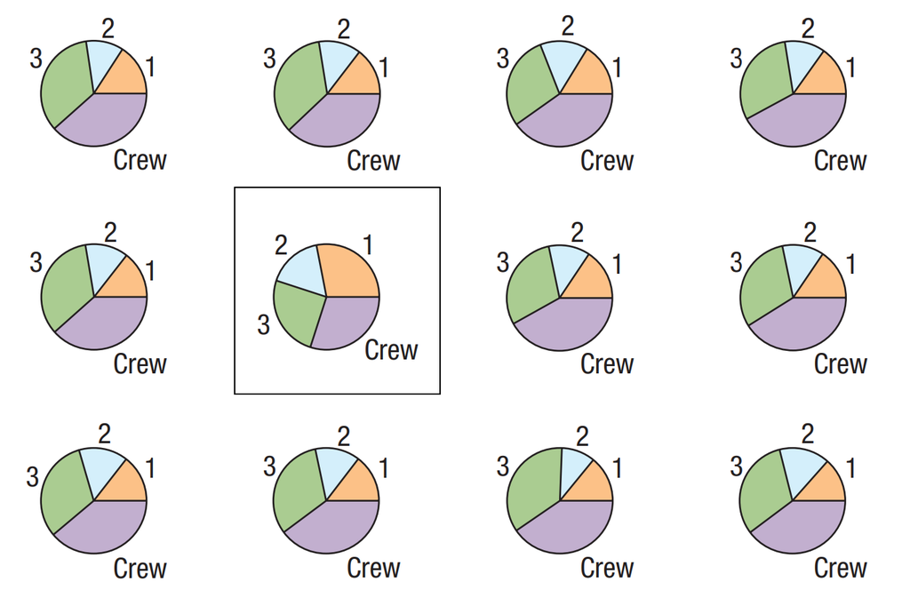

- Om den verkliga fördelningen är resultatet av samma slumpprocess som övriga fördelningar på bilden, då är det ett väldigt sällsynt (osannlikt) utfall
- Vi lutar därför åt att det finns ett samband!

## Kategoriska variabler och samband - kausalitet

- Antag att vi har konstaterat att det finns ett samband mellan biljettyp och överlevnad
- Betyder det att en förstaklassbiljett per automatik **medförde** att du hade en bättre chans att få en plats i en livbåt?
- **Nej, ett samband är inte samma sak som kausalitet!**
- Det kan finnas andra variabler som orsakar sambandet: Var social ställning en underliggande faktor? Prioriterades kvinnor och barn på 1910-talet?
- I fallet med cancer och fisk: äter människor som är hälsomedvetna mer fisk, samtidigt som de äter mer grönsaker och ägnar sig mer åt fysisk aktivitet?

## Kategoriska variabler och samband - kausalitet

**Att fundera över**

- Om det finns ett samband mellan **fler tv-apparater** i ett land och **högre medellivslängd**, beror det på att tv-tittande är nyttigt eller finns det någon annan bakomliggande variabel som spelar in?
- När du tittar på ett dataset, var medveten om att det alltid finns **dolda variabler** (*en: lurking variables*)
- Dolda variabler är variabler som inte är inkluderade i datamaterialet, men som kan vara högst relevanta i kontexten

## Ett (relativt) aktuellt exempel

- En [artikel på svt.se](https://www.svt.se/nyheter/lokalt/stockholm/handelshogskolan-drar-tillbaka-krav-pa-hogskoleprov) lyder som följer

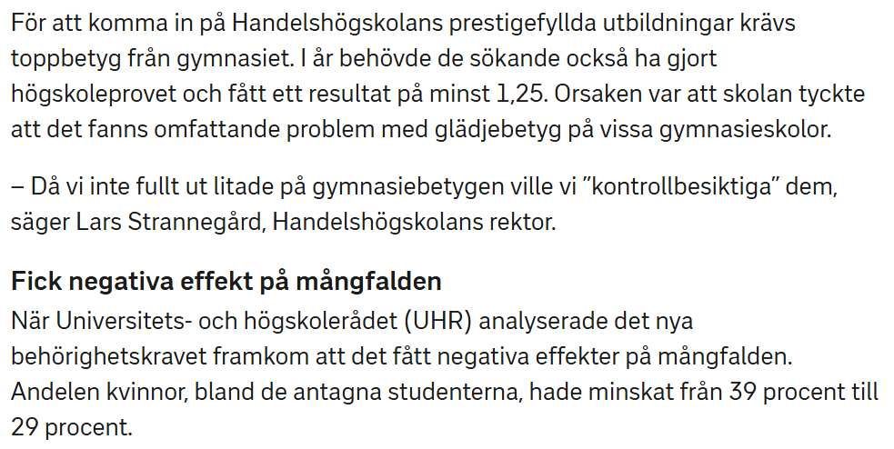

## Ett (relativt) aktuellt exempel

- Vissa tolkade artikeln illvilligt, och menade att kraven sänktes för att kvotera in kvinnor som egentligen inte förtjänar en plats på utbildningen
- Finns det någon som kan kontextualisera?
- Många har påpekat att färre kvinnor än män skriver HP alls, eftersom kvinnor i genomsnitt har högre gymnasiebetyg (och därför inte behöver HP)
- Den “minskade mångfalden” beror så inte på att kvinnor skriver dåliga HP, utan att många kvinnor inte behövt skriva HP (och därför ej klarar kravet)
- Finns det någon som kan identifiera en dold (och högst relevant) variabel?
- Ett givet exempel skulle kunna vara gymnasiebetyg

## Kategoriska variabler och samband - Simpsons paradox

- **Simpson’s paradox** innebär att ett samband mellan två variabler kan försvinna när datamaterialet **delas in i olika grupper**
- På sid 106 i kursboken hittar vi en korstabell som tycks peka på att män hade lättare än kvinnor att bli antagna som doktorander på UC Berkeley

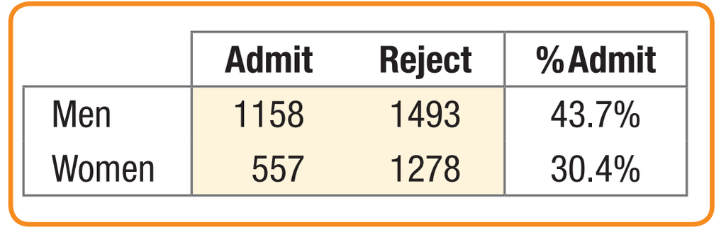

- Över 40 procent av männen som sökte blev antagna, men bara 30 procent av kvinnorna, och det ser ut som att kvinnor blev negativt särbehandlade

## Kategoriska variabler och samband - Simpsons paradox

- När vi ser samma siffror nedbrutna per fakultet (school) blir bilden en annan

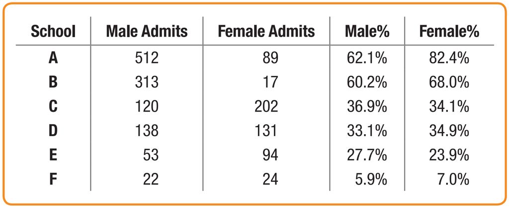

- På fyra av de sex fakulteterna var andelen antagna större bland kvinnor än bland män
- Hur går det ihop?

## Kategoriska variabler och samband - Simpsons paradox

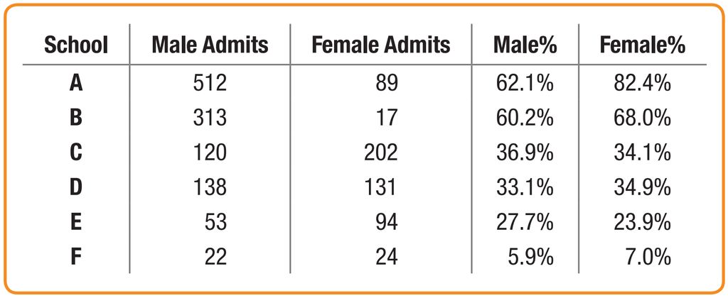

## Credits

Dessa slides skapades av Karl Sigfrid för kursen Statistik och Dataanalys I och har uppdaterats av Oskar Gustafsson och Valentin Zulj